# Биостатистика. ДЗ 1

95-871

2025-04-07

# ДЗ №1

## Загрузка пакетов и данных

```r
library(readxl)
library(dplyr)
```

```r
library(tidyr)
library(ggplot2)
library(qqplotr)
pima_data_src <- read_excel("pima.xlsx")
glimpse(pima_data_src)
```

```
## Rows: 768
## Columns: 9
## $ pregnant <dbl> 6, 1, 8, 1, 0, 5, 3, 10, 2, 8, 4, 10, 10, 1, 5, 7, 0, 7, 1, 1…
## $ glucose  <dbl> 148, 85, 183, 89, 137, 116, 78, 115, 197, 125, 110, 168, 139,…
## $ pressure <dbl> 72, 66, 64, 66, 40, 74, 50, 0, 70, 96, 92, 74, 80, 60, 72, 0,…
## $ triceps  <dbl> 35, 29, 0, 23, 35, 0, 32, 0, 45, 0, 0, 0, 0, 23, 19, 0, 47, 0…
## $ insulin  <dbl> 0, 0, 0, 94, 168, 0, 88, 0, 543, 0, 0, 0, 0, 846, 175, 0, 230…
## $ mass     <dbl> 33.6, 26.6, 23.3, 28.1, 43.1, 25.6, 31.0, 35.3, 30.5, 0.0, 37…
## $ pedigree <dbl> 0.627, 0.351, 0.672, 0.167, 2.288, 0.201, 0.248, 0.134, 0.158…
## $ age      <dbl> 50, 31, 32, 21, 33, 30, 26, 29, 53, 54, 30, 34, 57, 59, 51, 3…
## $ diabetes <chr> "pos", "neg", "pos", "neg", "pos", "neg", "pos", "neg", "pos"…
```

В данных встречаются нулевые значения. В описании датасета есть комментарий: While the UCI repository index claims that there are no missing values, closer inspection of the data shows several physical impossibilities, e.g., blood pressure or body mass index of 0. Учтём это для glucose, pressure, mass, triceps, insulin и будем считать 0 в этих столбцах пропуском. Иначе мы получим искажённые результаты описательных статистик. В столбце pregnant 0 возможен.

```r
pima_data <- pima_data_src %>%
  mutate(
    diabetes = as.factor(diabetes),
    glucose = ifelse(glucose == 0, NA, glucose),
    pressure = ifelse(pressure == 0, NA, pressure),
    mass = ifelse(mass == 0, NA, mass),
    triceps = ifelse(triceps == 0, NA, triceps),
    insulin = ifelse(insulin == 0, NA, insulin)
    )
summary(pima_data)
```

```
##     pregnant         glucose         pressure         triceps
##  Min.   : 0.000   Min.   : 44.0   Min.   : 24.00   Min.   : 7.00
##  1st Qu.: 1.000   1st Qu.: 99.0   1st Qu.: 64.00   1st Qu.:22.00
##  Median : 3.000   Median :117.0   Median : 72.00   Median :29.00
##  Mean   : 3.845   Mean   :121.7   Mean   : 72.41   Mean   :29.15
##  3rd Qu.: 6.000   3rd Qu.:141.0   3rd Qu.: 80.00   3rd Qu.:36.00
##  Max.   :17.000   Max.   :199.0   Max.   :122.00   Max.   :99.00
##                   NA's   :5       NA's   :35       NA's   :227
##     insulin            mass          pedigree           age        diabetes
##  Min.   : 14.00   Min.   :18.20   Min.   :0.0780   Min.   :21.00   neg:500
##  1st Qu.: 76.25   1st Qu.:27.50   1st Qu.:0.2437   1st Qu.:24.00   pos:268
##  Median :125.00   Median :32.30   Median :0.3725   Median :29.00
##  Mean   :155.55   Mean   :32.46   Mean   :0.4719   Mean   :33.24
##  3rd Qu.:190.00   3rd Qu.:36.60   3rd Qu.:0.6262   3rd Qu.:41.00
##  Max.   :846.00   Max.   :67.10   Max.   :2.4200   Max.   :81.00
##  NA's   :374      NA's   :11
```

## 1. Рассчитайте число наблюдений, среднее, стандартное отклонение, 1-й и 3-й квартили, минимум и максимум для переменных glucose, pressure, mass.

```r
vars_to_summarise <- c("glucose", "pressure", "mass")

stats_vars <- pima_data %>%
  summarise(
    across(
      all_of(vars_to_summarise),
      list(
        mean = ~ round(mean(.x, na.rm = TRUE), 2),
        sd = ~ round(sd(.x, na.rm = TRUE), 2),
        q1 = ~ quantile(.x, 0.25, na.rm = TRUE),
        q3 = ~ quantile(.x, 0.75, na.rm = TRUE),
        min = ~ min(.x, na.rm = TRUE),
        max = ~ max(.x, na.rm = TRUE),
        n = ~ sum(!is.na(.x))
      )
    )
  )

stats_vars <- stats_vars %>%
  pivot_longer(
    cols = everything(),
    names_to = c("variable", ".value"),
    names_sep = "_"
  ) %>%
  rename(
    "Переменная" = variable,
    "Среднее значение" = mean,
    "Стандартное отклонение" = sd,
    "1-й квартиль" = q1,
    "3-й квартиль" = q3,
    "Минимум" = min,
    "Максимум" = max,
    "Число наблюдений" = n
  )

print(stats_vars)
```

```
## # A tibble: 3 × 8
##   Переменная `Среднее значение` `Стандартное отклонение` `1-й квартиль`
##   <chr>                   <dbl>                    <dbl>          <dbl>
## 1 glucose                 122.                     30.5            99
## 2 pressure                 72.4                    12.4            64
## 3 mass                     32.5                     6.92           27.5
##   `3-й квартиль` Минимум Максимум `Число наблюдений`
##            <dbl>   <dbl>    <dbl>              <int>
## 1          141      44      199                  763
## 2           80      24      122                  733
## 3           36.6    18.2     67.1                757
```

## 2. Рассчитайте описательную статистику для переменной diabetes. Создайте на основе переменной age новую переменную age_group, которая будет отражать следующие возрастные группы: 21–35, 36–49 и 50+. Посчитайте описательную статистику для новой переменной.

```r
stats_diabetes <- pima_data %>%
  count(diabetes) %>%
  mutate(
    "%" = round((n / sum(n)) * 100, 2),
    "Интерпретация" = ifelse(diabetes == "neg", "отрицательно (диабет отсутствует)", "положительно (диабет присутствует)")
  )
print(stats_diabetes)
```

```
## # A tibble: 2 × 4
##   diabetes     n   `%` Интерпретация
##   <fct>    <int> <dbl> <chr>
## 1 neg        500  65.1 отрицательно (диабет отсутствует)
## 2 pos        268  34.9 положительно (диабет присутствует)
```

```r
stats_age_group <- pima_data %>%
  mutate(
    age_group = case_when(
      age >= 21 & age <= 35 ~ "21-35",
      age >= 36 & age <= 49 ~ "36-49",
      age >= 50 ~ "50+",
      TRUE ~ NA_character_
    )
  ) %>%
  count(age_group) %>%
  mutate(
    "%" = round((n / sum(n)) * 100, 2)
  )
print(stats_age_group)
```

```
## # A tibble: 3 × 3
##   age_group     n   `%`
##   <chr>     <int> <dbl>
## 1 21-35       498  64.8
## 2 36-49       181  23.6
## 3 50+          89  11.6
```

## 3. Постройте два ящика с усами для значений pos и neg соответственно переменной diabetes.

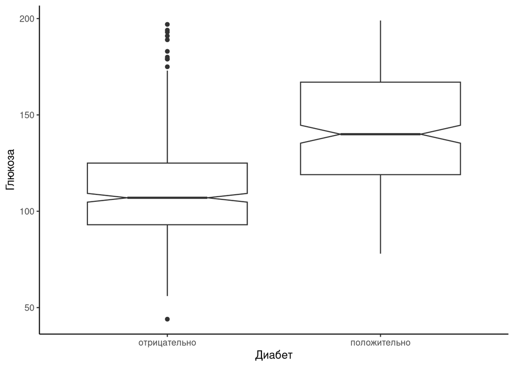

```r
pima_data %>%
  filter(!is.na(glucose)) %>%
  ggplot(aes(x = diabetes, y = glucose)) +
  geom_boxplot(notch = TRUE) +
  labs(x = "Диабет", y = "Глюкоза") +
  scale_x_discrete(labels = c(neg = "отрицательно", pos = "положительно")) +
  theme_classic()
```

## 4. Рассмотрите следующую статистическую гипотезу.

Проводят некоторое исследование пациентов с артериальной гипертензией. Предположим, что внедрение нового препарата в среднем лучше снижает их давление по сравнению со стандартной терапией.

Задайте seed для воспроизводимости результатов (функция set.seed()). Задайте размер выборки sample_size <- 30. Задайте значение среднего систолического артериального давления до приема нового препарата и после.

Затем:

1. Сформулируйте нулевую и альтернативную гипотезы.
2. Определите уровень значимости.
3. Выберите и примените статистический тест для проверки гипотезы и аргументируйте свой выбор.
4. Оцените и прокомментируйте статистическую значимость.

```r
set.seed(42)
sample_size <- 30
before <- rnorm(sample_size, mean = 135, sd = 15) + runif(sample_size, min = -10, max = 10)
after <- rnorm(sample_size, mean = 120, sd = 15) + runif(sample_size, min = -10, max = 10)
```

1. Формулирование нулевой и альтернативной гипотез

Предположим, что мы исследуем эффективность нового препарата в снижении систолического артериального давления у пациентов с артериальной гипертензией. Обозначим среднее систолическое артериальное давление до приема препарата как μ_before и после приема как μ_after. Мы хотим проверить, снижает ли новый препарат артериальное давление.

Нулевая гипотеза (H0): μ_before = μ_after или μ_before - μ_after = 0, т. е. новый препарат не снижает артериальное давление. Альтернативная гипотеза (H1): μ_before > μ_after или μ_before - μ_after > 0, т. е. новый препарат снижает артериальное давление.

2. Определение уровня значимости

Зададим уровень значимости α равным 0.05. Это означает, что если вероятность получить наблюдаемые данные (или более экстремальные) при условии, что нулевая гипотеза верна, меньше 0.05, мы отвергаем нулевую гипотезу.

3. Выбор и применение статистического теста

Тип данных: количественные

Подчиняются ли данные закону норм. распределения: да (см. проверку ниже)

Количество групп для сравнения: 2

Зависимы ли группы: да

Поскольку мы сравниваем среднее значение одной и той же группы до и после лечения, мы имеем дело с парными данными. Следовательно, подходящим статистическим тестом является парный t-тест (paired t-test).

Для применения t-теста должны быть соблюдены следующие условия:

1. Независимость наблюдений. В случае парного t-теста это означает, что пары наблюдений должны быть независимыми. Условие выполнено: данные получены от разных пациентов
2. Нормальность распределения. В случае парного t-теста это означает, что разности между парами наблюдений должны быть распределены нормально. Это связано с тем, что парный t-тест на самом деле является t-тестом для одной выборки, где выборкой являются разности между парами наблюдений. Условие выполнено: см. проверку ниже
3. Отсутствие выбросов. Условие выполнено: см. проверку ниже

```r
differences <- before - after

# (2) Проверка нормальности распределения разностей

## Тест Шапиро-Уилка: если p-значение > 0.05, то нет оснований отвергать гипотезу о нормальности
shapiro_test_result <- shapiro.test(differences)
print(shapiro_test_result)
```

```
##
##  Shapiro-Wilk normality test
##
## data:  differences
## W = 0.97096, p-value = 0.5659
```

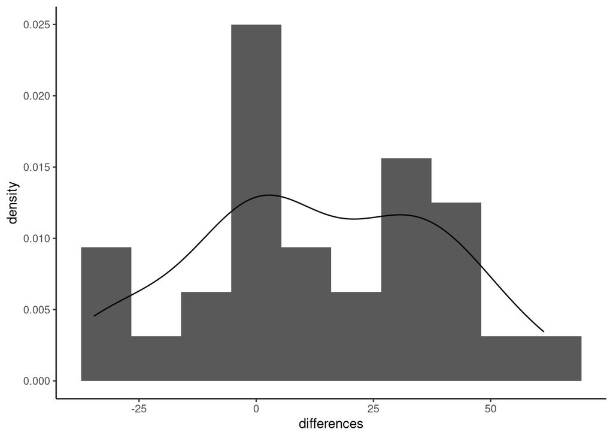

```r
## Визуальная проверка
ggplot(data.frame(differences), aes(x = differences)) +
  geom_histogram(aes(y = after_stat(density)), bins = 10) +
  stat_density(geom = "line") +
  theme_classic()
```

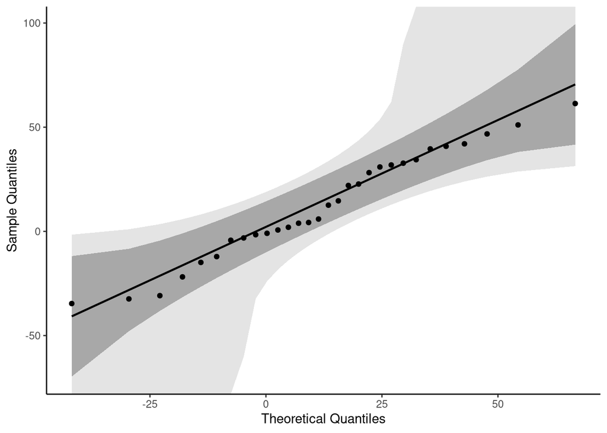

```r
ggplot(data.frame(differences),aes(sample = differences)) +
  geom_qq_band(bandType = "ks", fill = "#ddd") +
  geom_qq_band(bandType = "pointwise", fill = "#999") +
  stat_qq_line() +
  stat_qq_point() +
  labs(x = "Theoretical Quantiles", y = "Sample Quantiles") +
  theme_classic()
```

```r
# (3) Проверка отсутствия выбросов

## Если нет выбросов, то вектор будет пустым
boxplot.stats(differences)$out
```

```
## numeric(0)
```

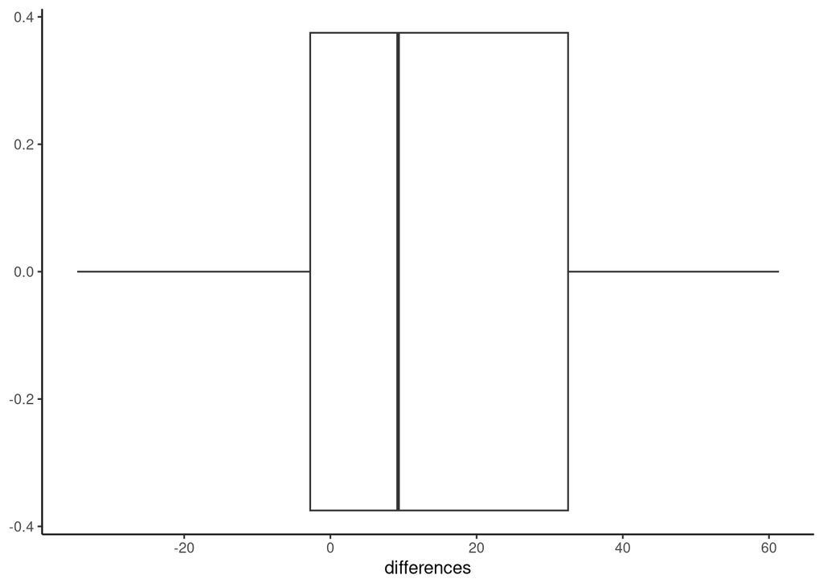

```r
## Визуальная проверка
ggplot(data.frame(differences), aes(x = differences)) +
  geom_boxplot() +
  theme_classic()
```

```r
# Применим парный t-тест
t_test_result <- t.test(before, after, paired = TRUE, alternative = "greater")
print(t_test_result)
```

```
##
##  Paired t-test
##
## data:  before and after
## t = 2.6184, df = 29, p-value = 0.00695
## alternative hypothesis: true mean difference is greater than 0
## 95 percent confidence interval:
##  4.352305      Inf
## sample estimates:
## mean difference
##        12.39694
```

4. Оценка статистической значимости

На основе результатов парного t-теста мы можем отвергнуть H0 и заключить, что средняя разность между before и after статистически значимо больше нуля (p-value = 0.00695 < 0.05). Это означает, что значения систолического артериального давления до приёма препарата в среднем больше, чем после приёма, с оценкой средней разности 12 мм рт. ст. Таким образом, мы имеем статистически значимые доказательства того, что новый препарат снижает артериальное давление.